# Biostat Final Data Analysis

Andrew Warrington

2024-07-06

## Read in the data:

```r
anole <- read.csv("data/cox_functional_ecology_data.csv")
ovx <- subset(anole, Treat == "OVX")
sham <- subset(anole, Treat == "SHAM")
```

## Explore summaries of the two groups:

```r
summary(ovx)
```

```
##   Animal.ID            Treat               Site                SVL1
##  Length:140         Length:140         Length:140         Min.   :38.00
##  Class :character   Class :character   Class :character   1st Qu.:42.00
##  Mode  :character   Mode  :character   Mode  :character   Median :43.00
##                                                           Mean   :43.09
##                                                           3rd Qu.:45.00
##                                                           Max.   :47.00
##
##      Mass1            SVL2           Mass2        Growth..mm.
##  Min.   :0.900   Min.   :42.00   Min.   :1.100   Min.   :-1.000
##  1st Qu.:1.300   1st Qu.:44.75   1st Qu.:1.800   1st Qu.: 2.000
##  Median :1.400   Median :45.00   Median :1.900   Median : 2.000
##  Mean   :1.503   Mean   :45.42   Mean   :1.954   Mean   : 2.309
##  3rd Qu.:1.700   3rd Qu.:46.00   3rd Qu.:2.200   3rd Qu.: 3.000
##  Max.   :2.200   Max.   :49.00   Max.   :2.900   Max.   : 7.000
##                                                  NA's   :1
##    Growth..g.      PHA...swelling       Hematocrit        Fat..g.
##  Min.   :-0.3000   Min.   :-0.05556   Min.   :0.2083   Min.   :0.0054
##  1st Qu.: 0.2000   1st Qu.: 0.10259   1st Qu.:0.2740   1st Qu.:0.1314
##  Median : 0.5000   Median : 0.18182   Median :0.3099   Median :0.1635
##  Mean   : 0.4453   Mean   : 0.20725   Mean   :0.3093   Mean   :0.1619
##  3rd Qu.: 0.7000   3rd Qu.: 0.30312   3rd Qu.:0.3399   3rd Qu.:0.2049
##  Max.   : 1.5000   Max.   : 0.56000   Max.   :0.4444   Max.   :0.2859
##  NA's   :1         NA's   :36         NA's   :78       NA's   :113
```

```r
summary(sham)
```

```
##   Animal.ID            Treat               Site                SVL1
##  Length:122         Length:122         Length:122         Min.   :39.00
##  Class :character   Class :character   Class :character   1st Qu.:42.00
##  Mode  :character   Mode  :character   Mode  :character   Median :43.00
##                                                           Mean   :42.96
##                                                           3rd Qu.:44.00
##                                                           Max.   :48.00
##
##      Mass1            SVL2           Mass2        Growth..mm.
##  Min.   :0.800   Min.   :41.00   Min.   :1.100   Min.   :-1.000
##  1st Qu.:1.300   1st Qu.:43.00   1st Qu.:1.500   1st Qu.: 1.000
##  Median :1.450   Median :45.00   Median :1.600   Median : 1.000
##  Mean   :1.453   Mean   :44.41   Mean   :1.622   Mean   : 1.426
##  3rd Qu.:1.600   3rd Qu.:45.00   3rd Qu.:1.700   3rd Qu.: 2.000
##  Max.   :2.000   Max.   :49.00   Max.   :2.000   Max.   : 4.000
##                  NA's   :1       NA's   :1       NA's   :1
##    Growth..g.      PHA...swelling       Hematocrit        Fat..g.
##  Min.   :-0.3000   Min.   :-0.15625   Min.   :0.1739   Min.   :0.00000
##  1st Qu.: 0.0000   1st Qu.: 0.02741   1st Qu.:0.2197   1st Qu.:0.00085
##  Median : 0.2000   Median : 0.10172   Median :0.2500   Median :0.00405
##  Mean   : 0.1661   Mean   : 0.12016   Mean   :0.2492   Mean   :0.01291
##  3rd Qu.: 0.3000   3rd Qu.: 0.22074   3rd Qu.:0.2727   3rd Qu.:0.00930
##  Max.   : 0.8000   Max.   : 0.42857   Max.   :0.3600   Max.   :0.15390
##  NA's   :1         NA's   :26         NA's   :72       NA's   :102
```

## The growth (in mm) five number summary for the OVX group:

- Min: **-1.0**
- 1st Quart: **2.0**
- Median: **2.0**
- 3rd Quart: **3.0**
- Max: **7.0**
- Mean: **2.309**
- SD: **1.274607**

```r
sd(ovx$Growth..mm., na.rm = TRUE)
```

```
## [1] 1.274607
```

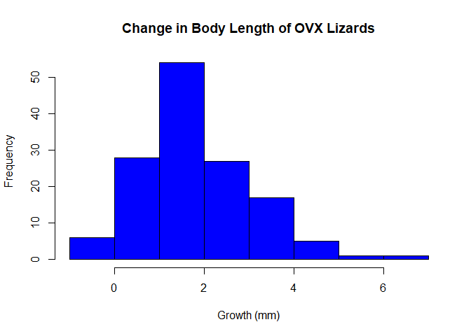

```r
hist(ovx$Growth..mm., main = "Change in Body Length of OVX Lizards", xlab = "Growth (mm)", col = "blue")
```

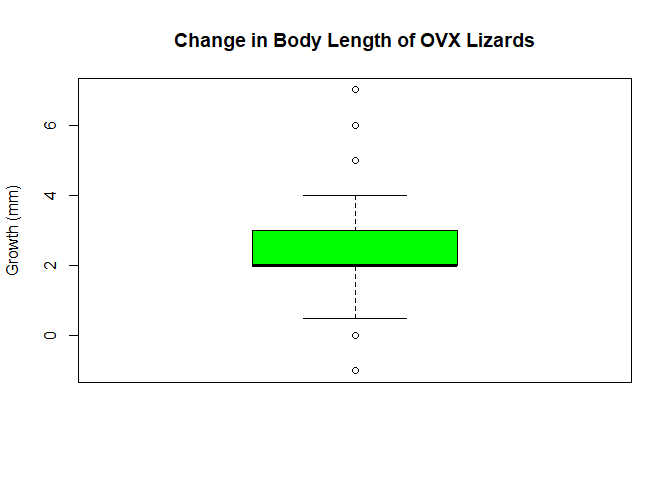

```r
boxplot(ovx$Growth..mm., main = "Change in Body Length of OVX Lizards", ylab = "Growth (mm)", col = "green")
```

The histogram and box plot visualizations indicate a uni-modal, right-skewed distribution. There are at least 3 high outliers and at least 2 low outliers.  
The center appears to be around 2.0 mm of growth, with a mean value of 2.309 mm, and a median value of 2.0 mm of growth.The mean being of higher value than the median is also indicative of a right-skewed distribution.

## Growth (in mm) 5 number summary for the sham group:

- Min: **-1.0**
- 1st Quart: **1.0**
- Median: **1.0**
- 3rd Quart: **2.0**
- Max: **4.0**
- Mean: **1.426**
- SD: **1.042156**

```r
sd(sham$Growth..mm., na.rm = TRUE)
```

```
## [1] 1.042156
```

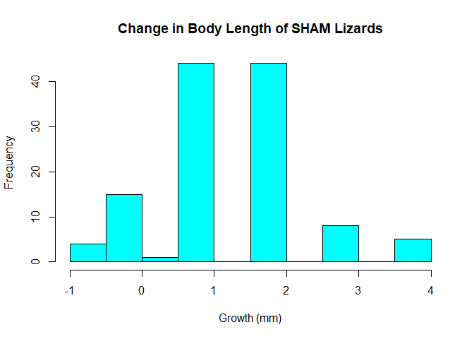

```r
hist(sham$Growth..mm., main = "Change in Body Length of SHAM Lizards", xlab = "Growth (mm)", col = "cyan")
```

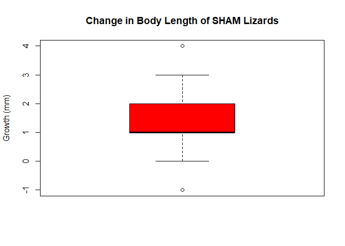

```r
boxplot(sham$Growth..mm., main = "Change in Body Length of SHAM Lizards", ylab = "Growth (mm)", col = "red")
```

The histogram and boxplot visualizations indicate the growth for the sham group follows a bimodal distribution. There is at least one high outlier and one low outlier.  
There are two centers, one around 1.0 mm and a center closer to 2.0 mm.  
The growth for sham group has a mean growth of 1.426 mm and a median growth of 1.0 mm.

## Hypothesis Test and Confidence Interval:

**H_0: mu_ovx = mu_sham**

**H_a: mu_ovx > mu_sham**

*Is there sufficient evidence to conclude that the mean growth of the ovx group is significantly higher than the mean sham growth?*

**Choosing a two-sample t test, one-sided, right-tailed:**

- Because we have two independent random samples and Population parameters m1,s1,m2,s2 are unknown.
- Our H_a is that the mean ovx growth in mm is significantly greater than the mean sham growth.

## Assumptions:

1. Sample Mean is Approximately Normal.
2. Data Comes from SRS (simple random sample) or random experiment
3. Observations are independent.
4. This data came from a random sample of Anoles.

*Even though the data itself is slightly right skewed (with outliers, both high and low), we have a large enough sample size to assume that the sample mean and standard deviation will be approximately Normal. The anole observations are independent.*

## Calculating T test statistic:

*Calling ovx group 1 and sham group 2*

- T_ts (T-test statistic)
- ovx: n = 139, (140 observations - 1 NA)
- sham: n = 121, (122 observations - 1 NA)

```r
(2.309 - 1.426)
```

```
## [1] 0.883
```

```r
(1.274607^2) / (139) + (1.042156^2) / (121)
```

```
## [1] 0.02066388
```

```r
sqrt(0.02066388)
```

```
## [1] 0.1437494
```

```r
0.883 / 0.1437494
```

```
## [1] 6.142634
```

**T_ts = 6.142634**

**Df = 120** (Degrees of freedom)

## P-Value Calculation:

```r
pt(6.142634, df = 120, lower.tail = FALSE)
```

```
## [1] 5.445521e-09
```

A one-sided, right-tailed t-test

**P-value = 5.445521e-09**

**Our cutoff**: significance level of 5% or 0.05 (alpha)

**5.445521e-09 < 0.05**, we *reject* the null hypothesis, which states that the mean growth of ovx and sham group are the same.

## P-value interpretation:

If the true mean growth for the ovx and sham group were equal (H_0 is true), then there is a 5.445521e-09 chance that we would have obtained the sample means we observed from both groups based on the data.

There is sufficient evidence to reject the null hypothesis (H_0), which states that the mean growth for the ovx and sham groups of anoles is the same, and conclude H_a, which states that the mean growth in mm ofr ovx group is greater than the sham group.

```r
# Calculate t*
qt(.025, df = 120)
```

```
## [1] -1.97993
```

```r
# t* = -1.97993

-1.97993 * 0.1437494 # equals m (margin of error) -> -0.2846137
```

```
## [1] -0.2846137
```

```r
(2.309 - 1.426) + (-0.2846137) # 0.5983863, lower bound of 95% CI
```

```
## [1] 0.5983863
```

```r
(2.309 - 1.426) - (-0.2846137) # 1.167614, upper bound of 95% CI
```

```
## [1] 1.167614
```

We are 95% confident that the difference in true mean growth for the ovx and shame group is between 0.5983863 and 1.167614 mm.

## Conclusion:

There is sufficient evidence to reject the null hypothesis (H_0), which states that the mean growth for the ovx and sham groups of anoles is the same, and conclude H_a, which states that the mean growth in mm ofr ovx group is greater than the sham group.

We are 95% confident that the difference in true mean growth for the ovx and shame group is between 0.5983863 and 1.167614 mm.

These findings are relevant because they suggest that there is a reproductive cost that is associated with the growth of female anoles. When reproductive mechanisms are removed in OVX, they experience a greater growth relative to the sham group that reproduces normally. The lack of growth that occurs in reproducing anoles could contribute to their lower annual survival rate.